# EDA

## Rental Listing Exploration Data Analysis

**Data Source - Kaagle**

> This project will help Rent Company like RentHop better handle fraud control, identify potential listing quality issues, and allow owners and agents to better understand renters’ needs and preferences.

#### Data fields

- bathrooms: number of bathrooms
- bedrooms: number of bathrooms
- building_id
- created
- description
- display_address
- features: a list of features about this apartment
- latitude
- listing_id
- longitude
- manager_id
- photos: a list of photo links. You are welcome to download the pictures yourselves from renthop's site, but they are the same as imgs.zip.
- price: in USD
- street_address
- interest_level: this is the target variable. It has 3 categories: 'high', 'medium', 'low'

```python
import os
import pandas as pd
import numpy as np
import matplotlib.pyplot as plt
import seaborn as sns
import gpxpy as gpx
import gpxpy.gpx
from sklearn.model_selection import train_test_split
from sklearn.preprocessing import StandardScaler
from wordcloud import WordCloud


%matplotlib inline
```

```python
# Set Working Directory
os.chdir('/Users/dangchong/Desktop/Marlabs/EDA/')
```

### Reading Data

```python
data = pd.read_json("train.json")
```

```python
data.head(3)
```

|  | bathrooms | bedrooms | building_id | created | description | display_address | features | interest_level | latitude | listing_id | longitude | manager_id | photos | price | street_address |
| --- | --- | --- | --- | --- | --- | --- | --- | --- | --- | --- | --- | --- | --- | --- | --- |
| 10 | 1.5 | 3 | 53a5b119ba8f7b61d4e010512e0dfc85 | 2016-06-24 07:54:24 | A Brand New 3 Bedroom 1.5 bath ApartmentEnjoy ... | Metropolitan Avenue | [] | medium | 40.7145 | 7211212 | -73.9425 | 5ba989232d0489da1b5f2c45f6688adc | [https://photos.renthop.com/2/7211212_1ed4542e... | 3000 | 792 Metropolitan Avenue |
| 10000 | 1.0 | 2 | c5c8a357cba207596b04d1afd1e4f130 | 2016-06-12 12:19:27 |  | Columbus Avenue | [Doorman, Elevator, Fitness Center, Cats Allow... | low | 40.7947 | 7150865 | -73.9667 | 7533621a882f71e25173b27e3139d83d | [https://photos.renthop.com/2/7150865_be3306c5... | 5465 | 808 Columbus Avenue |
| 100004 | 1.0 | 1 | c3ba40552e2120b0acfc3cb5730bb2aa | 2016-04-17 03:26:41 | Top Top West Village location, beautiful Pre-w... | W 13 Street | [Laundry In Building, Dishwasher, Hardwood Flo... | high | 40.7388 | 6887163 | -74.0018 | d9039c43983f6e564b1482b273bd7b01 | [https://photos.renthop.com/2/6887163_de85c427... | 2850 | 241 W 13 Street |

```python
# Reset index
data = data.reset_index().drop(['index'], axis = 1)
data.shape
```

```
(49352, 15)
```

There are 49352 observations, 15 variables. Interest_level is the response variable to predict with 3 values: 'high' 'medium' 'low'

```python
data.head(3)
```

|  | bathrooms | bedrooms | building_id | created | description | display_address | features | interest_level | latitude | listing_id | longitude | manager_id | photos | price | street_address |
| --- | --- | --- | --- | --- | --- | --- | --- | --- | --- | --- | --- | --- | --- | --- | --- |
| 0 | 1.5 | 3 | 53a5b119ba8f7b61d4e010512e0dfc85 | 2016-06-24 07:54:24 | A Brand New 3 Bedroom 1.5 bath ApartmentEnjoy ... | Metropolitan Avenue | [] | medium | 40.7145 | 7211212 | -73.9425 | 5ba989232d0489da1b5f2c45f6688adc | [https://photos.renthop.com/2/7211212_1ed4542e... | 3000 | 792 Metropolitan Avenue |
| 1 | 1.0 | 2 | c5c8a357cba207596b04d1afd1e4f130 | 2016-06-12 12:19:27 |  | Columbus Avenue | [Doorman, Elevator, Fitness Center, Cats Allow... | low | 40.7947 | 7150865 | -73.9667 | 7533621a882f71e25173b27e3139d83d | [https://photos.renthop.com/2/7150865_be3306c5... | 5465 | 808 Columbus Avenue |
| 2 | 1.0 | 1 | c3ba40552e2120b0acfc3cb5730bb2aa | 2016-04-17 03:26:41 | Top Top West Village location, beautiful Pre-w... | W 13 Street | [Laundry In Building, Dishwasher, Hardwood Flo... | high | 40.7388 | 6887163 | -74.0018 | d9039c43983f6e564b1482b273bd7b01 | [https://photos.renthop.com/2/6887163_de85c427... | 2850 | 241 W 13 Street |

### Missing Values

```python
# Check the missing values, but we found that it doesn't work for object data
data.isnull().sum()
```

```
bathrooms          0
bedrooms           0
building_id        0
created            0
description        0
display_address    0
features           0
interest_level     0
latitude           0
listing_id         0
longitude          0
manager_id         0
photos             0
price              0
street_address     0
dtype: int64
```

```python
data.dtypes
```

```
bathrooms          float64
bedrooms             int64
building_id         object
created             object
description         object
display_address     object
features            object
interest_level      object
latitude           float64
listing_id           int64
longitude          float64
manager_id          object
photos              object
price                int64
street_address      object
dtype: object
```

```python
# A DataFrame only contain object data
obj_data = data.drop(['bathrooms','bedrooms','latitude','longitude','price', 'listing_id'], axis=1)
```

```python
# Look for missing value in object data by using len() equal 0 or df.loc[i][j] == '0'
def feature_missing(df):
    mis = []
    for i, row in df.iterrows():
        for j, column in row.iteritems():
            if len(df.loc[i,j]) == 0 or df.loc[i,j] == '0':
                mis.append(i)
    return mis
```

```python
# How many rows of missing values
mis_list = feature_missing(data_obj)
len(mis_list)
```

```
16710
```

```python
# Remove duplicate index of rows
new_mis_list = list(set(mis_list))
print('Length of rows with missing value:', len(new_mis_list))
```

```
Length of rows with missing value: 13040
```

That's too many missing data, if we delete them, it will reduce size of data, and it's hard to use machine learning technique to predict the missing data, so I just keep them.

### Check of Distribution and Outliers

```python
data.describe()
```

|  | bathrooms | bedrooms | latitude | listing_id | longitude | price |
| --- | --- | --- | --- | --- | --- | --- |
| count | 49352.00000 | 49352.000000 | 49352.000000 | 4.935200e+04 | 49352.000000 | 4.935200e+04 |
| mean | 1.21218 | 1.541640 | 40.741545 | 7.024055e+06 | -73.955716 | 3.830174e+03 |
| std | 0.50142 | 1.115018 | 0.638535 | 1.262746e+05 | 1.177912 | 2.206687e+04 |
| min | 0.00000 | 0.000000 | 0.000000 | 6.811957e+06 | -118.271000 | 4.300000e+01 |
| 25% | 1.00000 | 1.000000 | 40.728300 | 6.915888e+06 | -73.991700 | 2.500000e+03 |
| 50% | 1.00000 | 1.000000 | 40.751800 | 7.021070e+06 | -73.977900 | 3.150000e+03 |
| 75% | 1.00000 | 2.000000 | 40.774300 | 7.128733e+06 | -73.954800 | 4.100000e+03 |
| max | 10.00000 | 8.000000 | 44.883500 | 7.753784e+06 | 0.000000 | 4.490000e+06 |

- The min of bathrooms and bedrooms are 0. Can you imagine a apartment without a bathroom? But somewhere in New York City, some people live in basement that don't have bathroom and bedroom.
- Min of latitude is 0 and max is 44.88. Latitude is mostly around 40.7. Min of longitude is -118.27 and max is 0. Most of longitude is around -73.9. Min of prince is 43 and max is 4.49Million. It is very likely latitude, longitude and price has ourliers.

### Remove Latitude Outlier

The 1st and 99th percentile of latitude is 40.6404 and 40.862047. So it is reasonable of thinking 0 to 44.8835 as ourliers.

```python
lat_pct = np.percentile(data.latitude, [1, 99]).tolist()
print ('latitude range:',lat_pct)
```

```
latitude range: [40.6404, 40.862047]
```

```python
data = data[(data['latitude'] >= 40.6404) & (data['latitude'] <= 40.862047)]
```

```python
data.shape
```

```
(48367, 15)
```

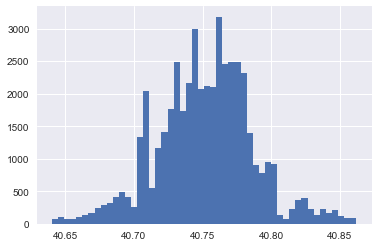

```python
data['latitude'].hist(bins = 50)
```

### Remove Longitude Outlier

```python
long_pct = np.percentile(data.longitude, [1, 99]).tolist()
print ('longitude range:',long_pct)
```

```
longitude range: [-74.0157, -73.8553]
```

```python
data = data[(data['longitude'] >= -74.0157) & (data['longitude'] <= -73.8553)]
```

```python
data.shape
```

```
(47442, 15)
```

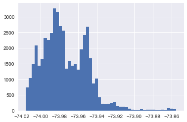

```python
data['longitude'].hist(bins = 50)
```

### Remove Outlier of Price

```python
price_pct = np.percentile(data.price, [1, 99]).tolist()
print ('price range:',price_pct)
```

```
price range: [1550.0, 13000.0]
```

```python
data = data[(data['price'] >= 1550.0) & (data['price'] <= 13000.0)]
```

```python
data.shape
```

[output not shown]

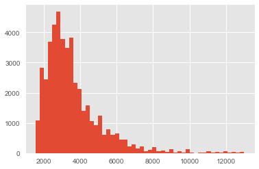

```python
data['price'].hist(bins = 50)
```

As is shown, the high interest level has the lowest median price, the low interest level has the highest price. That is, the higher the price, the less interest it is.

```python
data.groupby('interest_level').price.median()
```

```
interest_level
high      2595
low       3330
medium    2925
Name: price, dtype: int64
```

```python
data['price_per_bedroom'] = data.price / data.bedrooms

print(data.loc[:, ['interest_level', 'price', 'bedrooms', 'price_per_bedroom']]
.groupby('interest_level').agg('median'))
```

```
                price  bedrooms  price_per_bedroom
interest_level
high             2595         2        1666.666667
low              3330         1        2700.000000
medium           2925         2        1900.000000
```

### Feature Engineering

```python
# Number of Unique Address
unique_address = data['display_address'].unique()
print('Number of Unique Address:',len(unique_address))
```

```
Number of Unique Address: 8150
```

```python
# Unique feature
feature_value = data['features'].tolist()

feature_lst = []
for i in range(len(feature_value)):
    feature_lst += feature_value[i]

unique_feature = list(set(feature_lst))
print('Number of Unique Feature:',len(unique_feature))
```

```
Number of Unique Feature: 1507
```

#### Add more feature to DataSet for future prediction

```python
data['num_of_photos'] = data['photos'].apply(len)
data['num_of_features'] = data['features'].apply(len)
data['num_description_words'] = data['description'].apply(lambda x: len(x.split(" ")))
data['created'] = pd.to_datetime(data['created'])
data['created_year'] = data['created'].dt.year
data['created_month'] = data['created'].dt.month
data['created_day'] = data['created'].dt.day
data['day_of_week'] = data['created'].dt.weekday_name
```

```python
data.head(3)
```

|  | bathrooms | bedrooms | building_id | created | description | display_address | features | interest_level | latitude | listing_id | ... | photos | price | street_address | num_of_photos | num_of_features | num_description_words | created_year | created_month | created_day | day_of_week |
| --- | --- | --- | --- | --- | --- | --- | --- | --- | --- | --- | --- | --- | --- | --- | --- | --- | --- | --- | --- | --- | --- |
| 0 | 1.5 | 3 | 53a5b119ba8f7b61d4e010512e0dfc85 | 2016-06-24 07:54:24 | A Brand New 3 Bedroom 1.5 bath ApartmentEnjoy ... | Metropolitan Avenue | [] | medium | 40.7145 | 7211212 | ... | [https://photos.renthop.com/2/7211212_1ed4542e... | 3000 | 792 Metropolitan Avenue | 5 | 0 | 95 | 2016 | 6 | 24 | Friday |
| 1 | 1.0 | 2 | c5c8a357cba207596b04d1afd1e4f130 | 2016-06-12 12:19:27 |  | Columbus Avenue | [Doorman, Elevator, Fitness Center, Cats Allow... | low | 40.7947 | 7150865 | ... | [https://photos.renthop.com/2/7150865_be3306c5... | 5465 | 808 Columbus Avenue | 11 | 5 | 9 | 2016 | 6 | 12 | Sunday |
| 2 | 1.0 | 1 | c3ba40552e2120b0acfc3cb5730bb2aa | 2016-04-17 03:26:41 | Top Top West Village location, beautiful Pre-w... | W 13 Street | [Laundry In Building, Dishwasher, Hardwood Flo... | high | 40.7388 | 6887163 | ... | [https://photos.renthop.com/2/6887163_de85c427... | 2850 | 241 W 13 Street | 8 | 4 | 94 | 2016 | 4 | 17 | Sunday |

3 rows × 22 columns

### Data Visualization

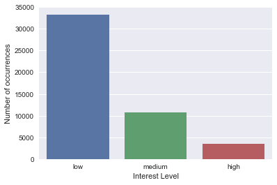

```python
import seaborn as sns
import matplotlib.pyplot as plt
sns.countplot(data.interest_level, order = ['low', 'medium','high'])
plt.xlabel('Interest Level')
plt.ylabel('Number of occurrences')
```

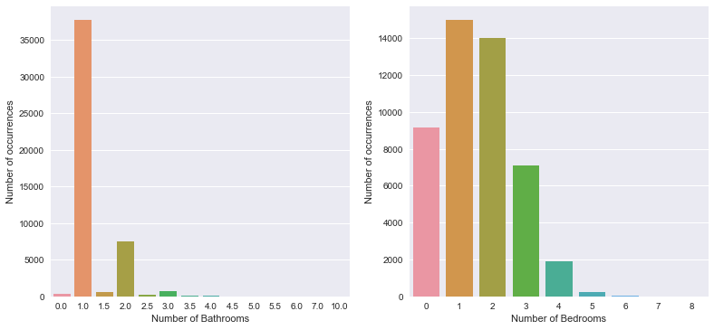

```python
fig = plt.figure(figsize=(13,13))
sns.countplot(data.bathrooms, ax = plt.subplot(221))
plt.xlabel('Number of Bathrooms')
plt.ylabel('Number of occurrences')

sns.countplot(data.bedrooms, ax = plt.subplot(222))
plt.xlabel('Number of Bedrooms')
plt.ylabel('Number of occurrences')
```

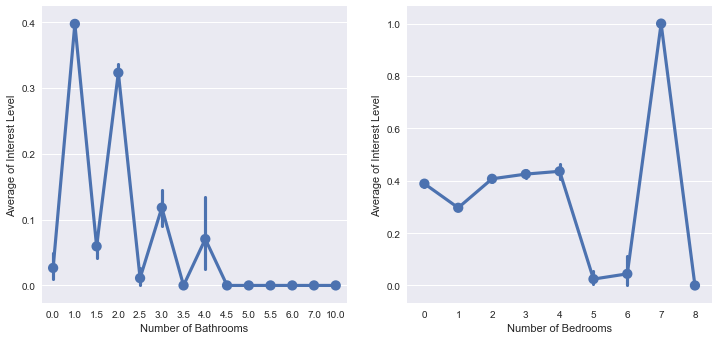

```python
# Quantitative substitute of Interest Level
data['interest'] = np.where(data.interest_level == 'low', 0,
                   np.where(data.interest_level == 'medium', 1,2)
                    )

fig = plt.figure(figsize=(12,12))

# Average number of Bathrooms per Interest Level
sns.pointplot(x = 'bathrooms', y='interest', data = data, ax = plt.subplot(221))
plt.xlabel('Number of Bathrooms')
plt.ylabel('Average of Interest Level')

# Average number of Bedrooms per Interest Level
sns.pointplot(x = 'bedrooms', y='interest', data = data, ax = plt.subplot(222))
plt.xlabel('Number of Bedrooms')
plt.ylabel('Average of Interest Level')
```

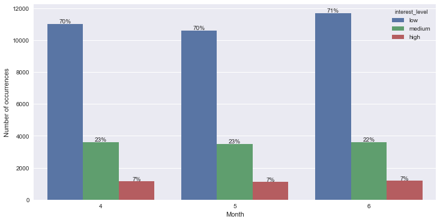

```python
# Interest per month
fig = plt.figure(figsize=(12,6))
ax = sns.countplot(x="created_month", hue="interest_level", hue_order=['low', 'medium', 'high'],
                   data=data);
plt.xlabel('Month');
plt.ylabel('Number of occurrences')

### Adding percents over bars
height = [p.get_height() for p in ax.patches]
ncol = int(len(height)/3)
total = [height[i] + height[i + ncol] + height[i + 2*ncol] for i in range(ncol)] * 3
for i, p in enumerate(ax.patches):
    ax.text(p.get_x()+p.get_width()/2,
            height[i] + 50,
            '{:1.0%}'.format(height[i]/total[i]),
            ha="center")
```

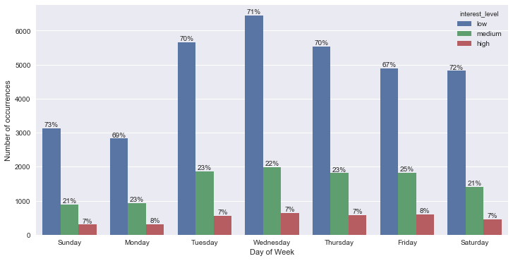

```python
# Interest per week
fig = plt.figure(figsize=(12,6))
ax = sns.countplot(x="day_of_week", hue="interest_level", hue_order=['low', 'medium', 'high'],
                   data=data, order=['Sunday', 'Monday', 'Tuesday', 'Wednesday', 'Thursday', 'Friday', 'Saturday']);
plt.xlabel('Day of Week');
plt.ylabel('Number of occurrences')

### Adding percents over bars
height = [p.get_height() for p in ax.patches]
ncol = int(len(height)/3)
total = [height[i] + height[i + ncol] + height[i + 2*ncol] for i in range(ncol)] * 3
for i, p in enumerate(ax.patches):
    ax.text(p.get_x()+p.get_width()/2,
            height[i] + 50,
            '{:1.0%}'.format(height[i]/total[i]),
            ha="center")
```

```python
# Most popular buildings
data['building_id'].value_counts().nlargest(10)
```

```
0                                   8286
96274288c84ddd7d5c5d8e425ee75027     275
11e1dec9d14b1a9e528386a2504b3afc     215
80a120d6bc3aba97f40fee8c2204524b     213
bb8658a3e432fb62a440615333376345     212
f68bf347f99df026f4faad43cc604048     191
c94301249b8c09429d329864d58e5b82     167
ce6d18bf3238e668b2bf23f4110b7b67     165
57ef86c28a8ae482dc3a3c3af28e8e48     159
128d4af0683efc5e1eded8dc8044d5e3     153
Name: building_id, dtype: int64
```

```python
# Most popylar address
data['display_address'].value_counts().nlargest(10)
```

```
Broadway             438
East 34th Street     355
Second Avenue        349
Wall Street          332
West 37th Street     287
West Street          258
First Avenue         244
Gold Street          241
Washington Street    237
York Avenue          228
Name: display_address, dtype: int64
```

```python
# Remove symbols and make address more simple
data['display_address2'] = data.display_address.map(lambda x: " ".join(x.strip("-,.$*!#&\'\t").replace("'",'').lower()\
                                                                         .replace('street', 'st').replace('avenue', 'ave')\
                                                                         .replace('east', 'E').replace('west', 'W').split()))
# Most popular addresses
data['display_address2'].value_counts(dropna = False)[:20]
```

```
wall st           451
broadway          419
second ave        370
E 34th st         358
john st           346
gold st           345
york ave          316
washington st     304
columbus ave      292
W 37th st         289
lexington ave     283
water st          280
first ave         268
thompson st       238
christopher st    226
W st              219
amsterdam ave     212
W end ave         209
third ave         203
E 39th st         201
Name: display_address2, dtype: int64
```

```
(-0.5, 599.5, 299.5, -0.5)
```

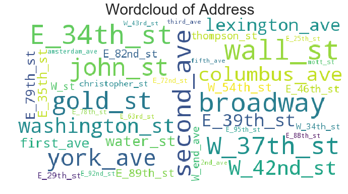

```python
# Join address by '_'
display_address_word2 = ' '.join(data.display_address2.map(lambda x: '_'.join(x.strip().split(" "))))

#Plot for wordcloud
plt.figure(figsize=(12, 6))
wordcloud = WordCloud(background_color='white', width=600, height=300, max_font_size=50, max_words=40).generate(display_address_word2)
wordcloud.recolor(random_state=0)
plt.imshow(wordcloud)
plt.title("Wordcloud of Address", fontsize=30)
plt.axis("off")
```

### Next I will begin to build models based on the analysis above .

```python
grp = data.groupby(['latitude', 'longitude'])
cnt1 = grp.interest_level.apply(lambda x: x.value_counts()).reset_index(name="interest_level_cnts")
cnt2 = grp.size().reset_index(name = 'size')
cnt = pd.merge(cnt1, cnt2, how = 'inner', on = ["latitude", "longitude"])
cnt['pct'] = cnt.interest_level_cnts / cnt.loc[:, 'size']
```